# Term Deposit Sale

## Goal

Using the data collected from existing customers, build a model that will help the marketing team identify potential customers who are relatively more likely to subscribe term deposit and thus increase their hit ratio.

#### Libraries and set-up

```python
import pandas as pd
import numpy as np
import matplotlib.pyplot as plt
import seaborn as sns

from sklearn import metrics
from sklearn import tree
from sklearn.model_selection import train_test_split as tts
from sklearn.tree import DecisionTreeClassifier
from sklearn.feature_extraction.text import CountVectorizer
from IPython.display import Image
from os import system

%matplotlib inline

from IPython.core.interactiveshell import InteractiveShell

InteractiveShell.ast_node_interactivity = "all"

palette = 'Set2'

pd.set_option('display.max_columns', None)
```

```python
def print_count(col, ordered=True):
    plt.figure(figsize=(15,8))
    plt.title(col)
    if ordered:
        ax = sns.countplot(raw_data[col], palette=palette, order=raw_data[col].value_counts().index)
    else:
        ax = sns.countplot(raw_data[col], palette=palette)

    for p in ax.patches:
        ax.annotate('{:.0f}'.format(p.get_height()), (p.get_x()+.15, p.get_height()+1))

def print_kde(col):
    plt.figure(figsize=(25,5))
    sns.distplot(raw_data[col]);
```

#### Data import

```python
# raw_data for completely unmodified data
raw_data = pd.read_csv('bank-full.csv')

# data for modifications/imputations
data = pd.read_csv('bank-full.csv')

# dataset where we are removing outliers to see if this gives us a better model
data_no = pd.read_csv('bank-full.csv')
```

## Univariate Analysis

### General

```python
raw_data.info()
```

```
<class 'pandas.core.frame.DataFrame'>
RangeIndex: 45211 entries, 0 to 45210
Data columns (total 17 columns):
 #   Column     Non-Null Count  Dtype
---  ------     --------------  -----
 0   age        45211 non-null  int64
 1   job        45211 non-null  object
 2   marital    45211 non-null  object
 3   education  45211 non-null  object
 4   default    45211 non-null  object
 5   balance    45211 non-null  int64
 6   housing    45211 non-null  object
 7   loan       45211 non-null  object
 8   contact    45211 non-null  object
 9   day        45211 non-null  int64
 10  month      45211 non-null  object
 11  duration   45211 non-null  int64
 12  campaign   45211 non-null  int64
 13  pdays      45211 non-null  int64
 14  previous   45211 non-null  int64
 15  poutcome   45211 non-null  object
 16  Target     45211 non-null  object
dtypes: int64(7), object(10)
memory usage: 5.9+ MB
```

```python
raw_data.shape
```

```
(45211, 17)
```

```python
raw_data.isnull().values.any()
```

```
False
```

```python
raw_data.head(10)
```

|  | age | job | marital | education | default | balance | housing | loan | contact | day | month | duration | campaign | pdays | previous | poutcome | Target |
| --- | --- | --- | --- | --- | --- | --- | --- | --- | --- | --- | --- | --- | --- | --- | --- | --- | --- |
| 0 | 58 | management | married | tertiary | no | 2143 | yes | no | unknown | 5 | may | 261 | 1 | -1 | 0 | unknown | no |
| 1 | 44 | technician | single | secondary | no | 29 | yes | no | unknown | 5 | may | 151 | 1 | -1 | 0 | unknown | no |
| 2 | 33 | entrepreneur | married | secondary | no | 2 | yes | yes | unknown | 5 | may | 76 | 1 | -1 | 0 | unknown | no |
| 3 | 47 | blue-collar | married | unknown | no | 1506 | yes | no | unknown | 5 | may | 92 | 1 | -1 | 0 | unknown | no |
| 4 | 33 | unknown | single | unknown | no | 1 | no | no | unknown | 5 | may | 198 | 1 | -1 | 0 | unknown | no |
| 5 | 35 | management | married | tertiary | no | 231 | yes | no | unknown | 5 | may | 139 | 1 | -1 | 0 | unknown | no |
| 6 | 28 | management | single | tertiary | no | 447 | yes | yes | unknown | 5 | may | 217 | 1 | -1 | 0 | unknown | no |
| 7 | 42 | entrepreneur | divorced | tertiary | yes | 2 | yes | no | unknown | 5 | may | 380 | 1 | -1 | 0 | unknown | no |
| 8 | 58 | retired | married | primary | no | 121 | yes | no | unknown | 5 | may | 50 | 1 | -1 | 0 | unknown | no |
| 9 | 43 | technician | single | secondary | no | 593 | yes | no | unknown | 5 | may | 55 | 1 | -1 | 0 | unknown | no |

```python
data_cols = list(raw_data)

num_cols = ['age','balance','day','duration','campaign','pdays','previous']
cat_cols = ['job','marital','education','default','housing','loan','contact','poutcome','Target']

for c in data_cols:
    print(c + ':')
    print(raw_data[c].unique())
    print('')
```

```
age:
[58 44 33 47 35 28 42 43 41 29 53 57 51 45 60 56 32 25 40 39 52 46 36 49
 59 37 50 54 55 48 24 38 31 30 27 34 23 26 61 22 21 20 66 62 83 75 67 70
 65 68 64 69 72 71 19 76 85 63 90 82 73 74 78 80 94 79 77 86 95 81 18 89
 84 87 92 93 88]

job:
['management' 'technician' 'entrepreneur' 'blue-collar' 'unknown'
 'retired' 'admin.' 'services' 'self-employed' 'unemployed' 'housemaid'
 'student']

marital:
['married' 'single' 'divorced']

education:
['tertiary' 'secondary' 'unknown' 'primary']

default:
['no' 'yes']

balance:
[ 2143    29     2 ...  8205 14204 16353]

housing:
['yes' 'no']

loan:
['no' 'yes']

contact:
['unknown' 'cellular' 'telephone']

day:
[ 5  6  7  8  9 12 13 14 15 16 19 20 21 23 26 27 28 29 30  2  3  4 11 17
 18 24 25  1 10 22 31]

month:
['may' 'jun' 'jul' 'aug' 'oct' 'nov' 'dec' 'jan' 'feb' 'mar' 'apr' 'sep']

duration:
```

[output cut: 35 more lines]

```
 562 761 492 775 579 493 464 760 466 465 656 831 490 432 655 427 749 838
 769 587 778 854 779 850 771 594 842 589 603 484 489 486 409 444 680 808
 485 503 690 772 774 526 420 528 500 826 804 508 547 805 541 543 871 550
 530]

previous:
[  0   3   1   4   2  11  16   6   5  10  12   7  18   9  21   8  14  15
  26  37  13  25  20  27  17  23  38  29  24  51 275  22  19  30  58  28
  32  40  55  35  41]

poutcome:
['unknown' 'failure' 'other' 'success']

Target:
['no' 'yes']
```

```python
raw_data.describe()
```

|  | age | balance | day | duration | campaign | pdays | previous |
| --- | --- | --- | --- | --- | --- | --- | --- |
| count | 45211.000000 | 45211.000000 | 45211.000000 | 45211.000000 | 45211.000000 | 45211.000000 | 45211.000000 |
| mean | 40.936210 | 1362.272058 | 15.806419 | 258.163080 | 2.763841 | 40.197828 | 0.580323 |
| std | 10.618762 | 3044.765829 | 8.322476 | 257.527812 | 3.098021 | 100.128746 | 2.303441 |
| min | 18.000000 | -8019.000000 | 1.000000 | 0.000000 | 1.000000 | -1.000000 | 0.000000 |
| 25% | 33.000000 | 72.000000 | 8.000000 | 103.000000 | 1.000000 | -1.000000 | 0.000000 |
| 50% | 39.000000 | 448.000000 | 16.000000 | 180.000000 | 2.000000 | -1.000000 | 0.000000 |
| 75% | 48.000000 | 1428.000000 | 21.000000 | 319.000000 | 3.000000 | -1.000000 | 0.000000 |
| max | 95.000000 | 102127.000000 | 31.000000 | 4918.000000 | 63.000000 | 871.000000 | 275.000000 |

```python
pdays_no_neg = raw_data[raw_data['pdays'] != -1]
pdays_no_neg.describe()
```

|  | age | balance | day | duration | campaign | pdays | previous |
| --- | --- | --- | --- | --- | --- | --- | --- |
| count | 8257.000000 | 8257.000000 | 8257.000000 | 8257.000000 | 8257.000000 | 8257.000000 | 8257.000000 |
| mean | 40.953131 | 1556.880102 | 14.289209 | 260.118687 | 2.056195 | 224.577692 | 3.177546 |
| std | 11.425180 | 3060.593186 | 7.919176 | 235.208105 | 1.561169 | 115.344035 | 4.560820 |
| min | 18.000000 | -1884.000000 | 1.000000 | 1.000000 | 1.000000 | 1.000000 | 1.000000 |
| 25% | 33.000000 | 168.000000 | 7.000000 | 113.000000 | 1.000000 | 133.000000 | 1.000000 |
| 50% | 38.000000 | 602.000000 | 14.000000 | 193.000000 | 2.000000 | 194.000000 | 2.000000 |
| 75% | 48.000000 | 1743.000000 | 20.000000 | 324.000000 | 2.000000 | 327.000000 | 4.000000 |
| max | 93.000000 | 81204.000000 | 31.000000 | 2219.000000 | 16.000000 | 871.000000 | 275.000000 |

```python
raw_data.nunique()
```

```
age            77
job            12
marital         3
education       4
default         2
balance      7168
housing         2
loan            2
contact         3
day            31
month          12
duration     1573
campaign       48
pdays         559
previous       41
poutcome        4
Target          2
dtype: int64
```

### Age

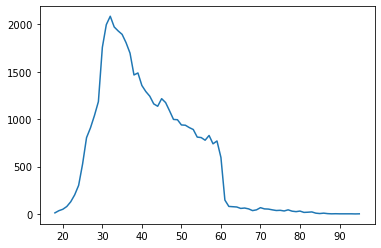

```python
raw_data['age'].value_counts().sort_index().plot.line();
```

### Job

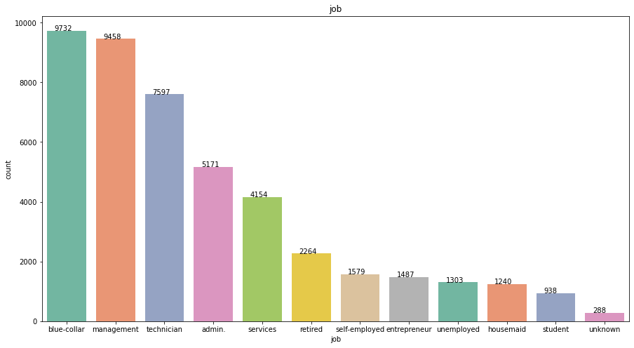

```python
print_count('job')
```

### Marital Status

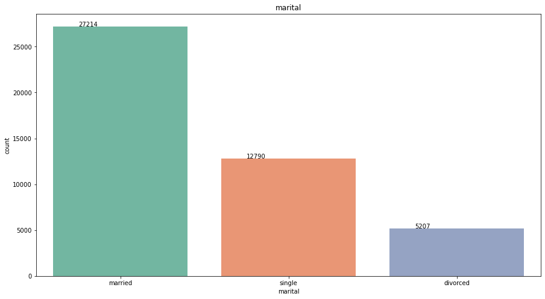

```python
print_count('marital')
```

### Education Level

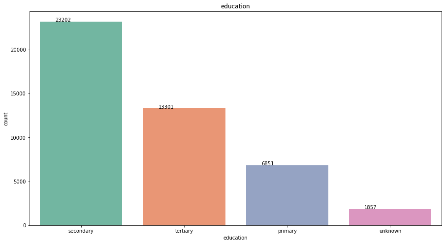

```python
print_count('education')
```

### Credit in default

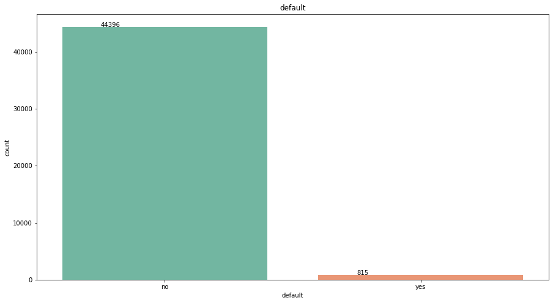

```python
print_count('default')
```

### Has a mortgage

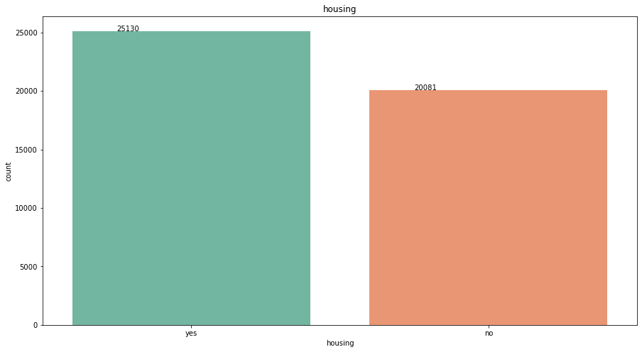

```python
print_count('housing')
```

### Has a personal loan

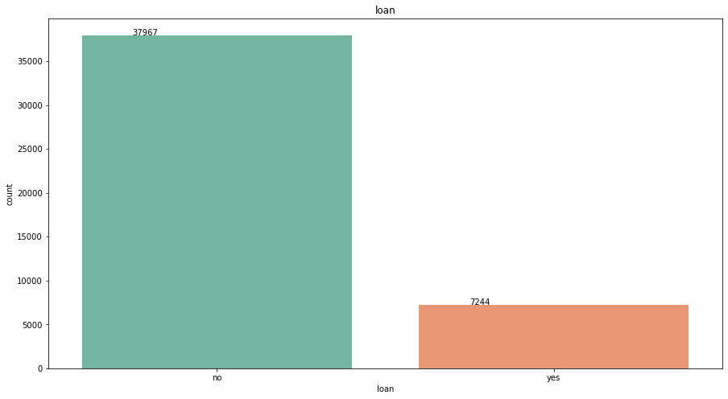

```python
print_count('loan')
```

### Balance in account

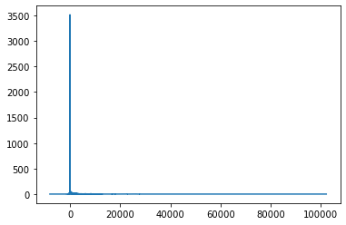

```python
raw_data['balance'].value_counts().sort_index().plot.line();
```

```python
raw_data['balance'].describe()
```

```
count     45211.000000
mean       1362.272058
std        3044.765829
min       -8019.000000
25%          72.000000
50%         448.000000
75%        1428.000000
max      102127.000000
Name: balance, dtype: float64
```

### Contact type

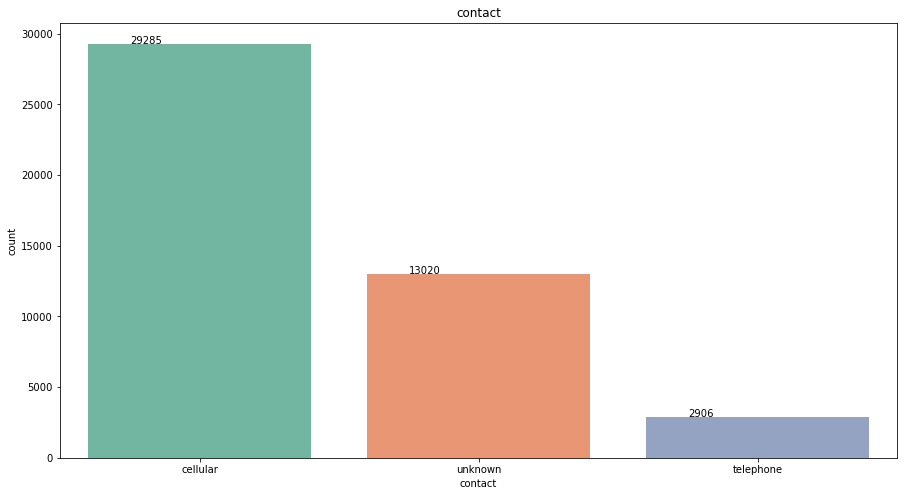

```python
print_count('contact')
```

*Question*: What causes contact to be "unknown"?

### Last contact (month and day)

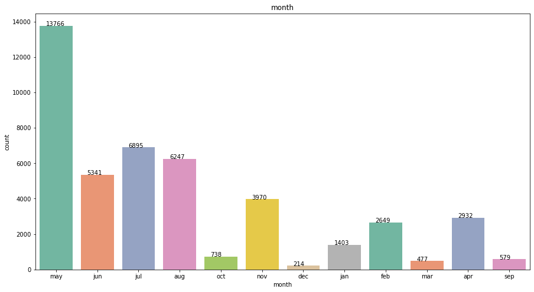

```python
print_count('month', False)

# Skewed data here may not be bad due to seasonal changes, promotions, etc.
```

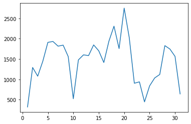

```python
raw_data['day'].value_counts().sort_index().plot.line();

# This data should be much less skewed because day of the month shouldn't matter at all.
# Weekends (which will change month-to-month) shouldn't affect the data this much, either.
```

### Duration of last contact

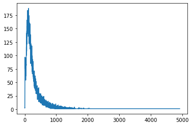

```python
raw_data['duration'].value_counts().sort_index().plot.line();
```

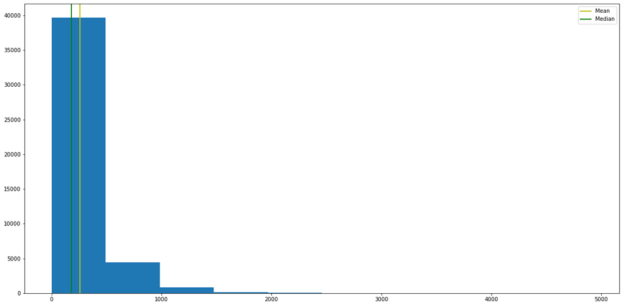

```python
# By itself this is not very interesting, but displaying here
# for comparison with similar bivariate chart below

plt.figure(figsize=(20,10))
plt.hist(raw_data['duration'])
plt.axvline(raw_data['duration'].mean(), color='y', linewidth=2, label='Mean')
plt.axvline(raw_data['duration'].median(), color='g', linewidth=2, label='Median')
plt.legend();
```

### Number of contacts

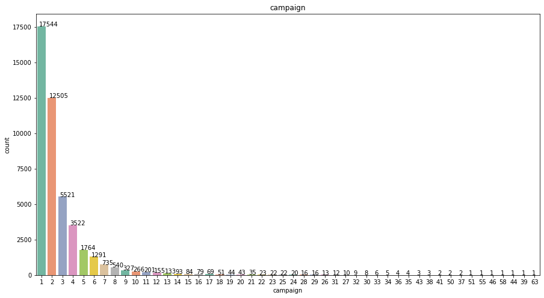

```python
print_count('campaign')
```

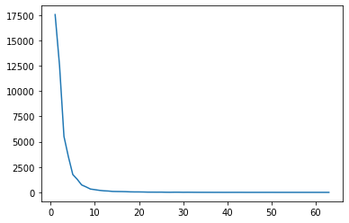

```python
raw_data['campaign'].value_counts().sort_index().plot.line();
```

### Days since last contact

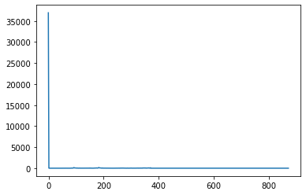

```python
raw_data['pdays'].value_counts().sort_index().plot.line();
```

```python
raw_data['pdays'].describe()
```

```
count    45211.000000
mean        40.197828
std        100.128746
min         -1.000000
25%         -1.000000
50%         -1.000000
75%         -1.000000
max        871.000000
Name: pdays, dtype: float64
```

```python
raw_data['pdays'].value_counts()
```

```
-1      36954
 182      167
 92       147
 183      126
 91       126
        ...
 749        1
 717        1
 589        1
 493        1
 32         1
Name: pdays, Length: 559, dtype: int64
```

*Look at the data without the -1 values*

```python
pdays_no_neg1 = raw_data['pdays'].replace(-1, np.nan)

pdays_no_neg1.describe()
```

```
count    8257.000000
mean      224.577692
std       115.344035
min         1.000000
25%       133.000000
50%       194.000000
75%       327.000000
max       871.000000
Name: pdays, dtype: float64
```

### Previous contacts

```python
raw_data['previous'].value_counts()
```

```
0      36954
1       2772
2       2106
3       1142
4        714
5        459
6        277
7        205
8        129
9         92
10        67
11        65
12        44
13        38
15        20
```

[output cut: 27 more lines]

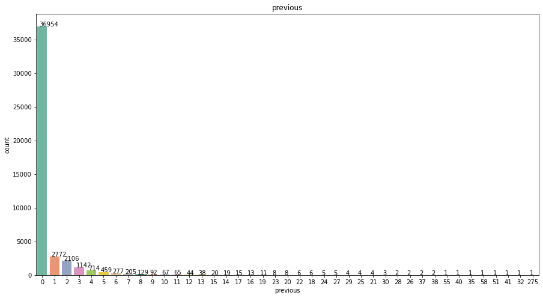

```python
print_count('previous')
```

### Previous campaign outcome

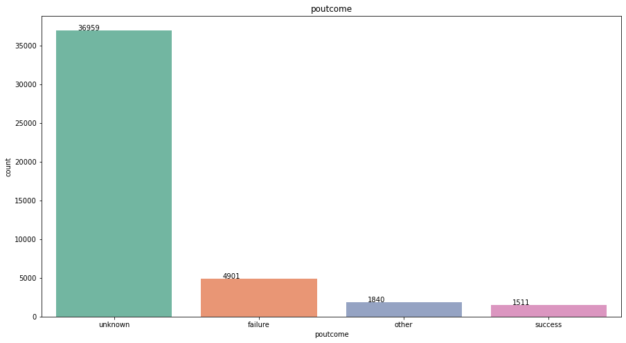

```python
print_count('poutcome')
```

*Question*: What is "other" in this context? How can a contact end in neither success nor failure?

### Term deposit subscription

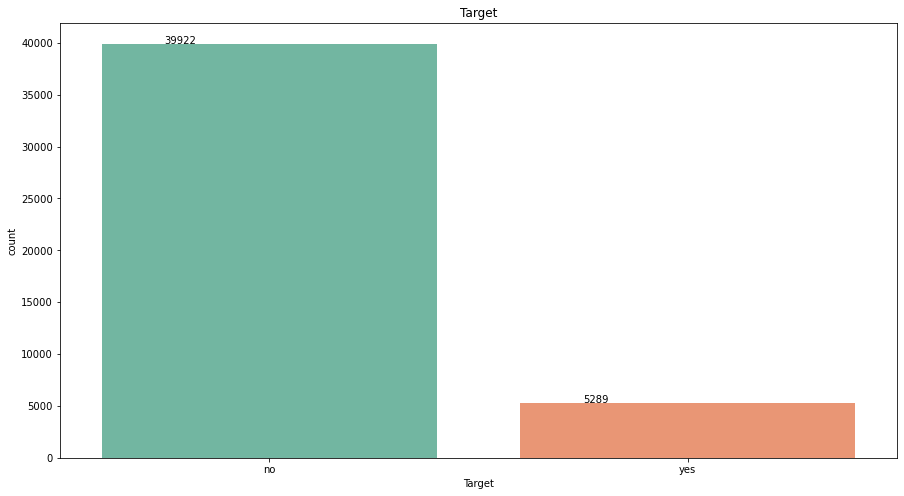

```python
print_count('Target')
```

## Bivariate Analysis

```python
raw_data.corr()
```

|  | age | balance | day | duration | campaign | pdays | previous |
| --- | --- | --- | --- | --- | --- | --- | --- |
| age | 1.000000 | 0.097783 | -0.009120 | -0.004648 | 0.004760 | -0.023758 | 0.001288 |
| balance | 0.097783 | 1.000000 | 0.004503 | 0.021560 | -0.014578 | 0.003435 | 0.016674 |
| day | -0.009120 | 0.004503 | 1.000000 | -0.030206 | 0.162490 | -0.093044 | -0.051710 |
| duration | -0.004648 | 0.021560 | -0.030206 | 1.000000 | -0.084570 | -0.001565 | 0.001203 |
| campaign | 0.004760 | -0.014578 | 0.162490 | -0.084570 | 1.000000 | -0.088628 | -0.032855 |
| pdays | -0.023758 | 0.003435 | -0.093044 | -0.001565 | -0.088628 | 1.000000 | 0.454820 |
| previous | 0.001288 | 0.016674 | -0.051710 | 0.001203 | -0.032855 | 0.454820 | 1.000000 |

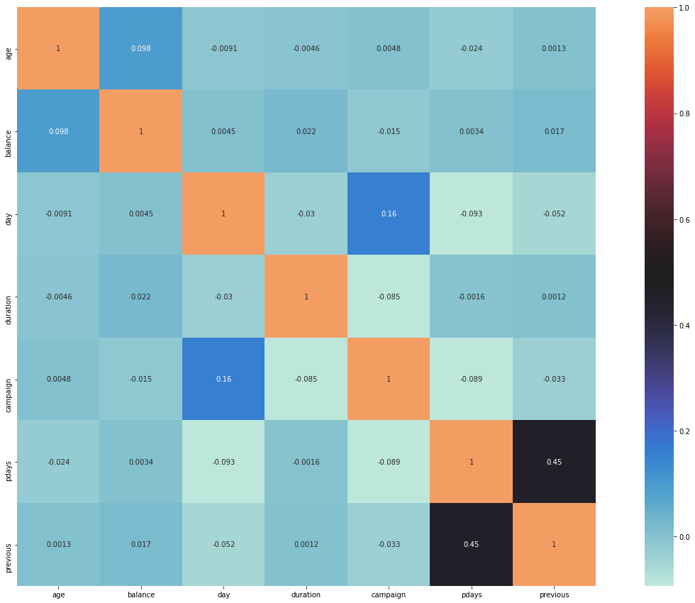

```python
plt.figure(figsize=(25,15))
sns.heatmap(raw_data.corr(), annot=True, square=True, center=0.5);
```

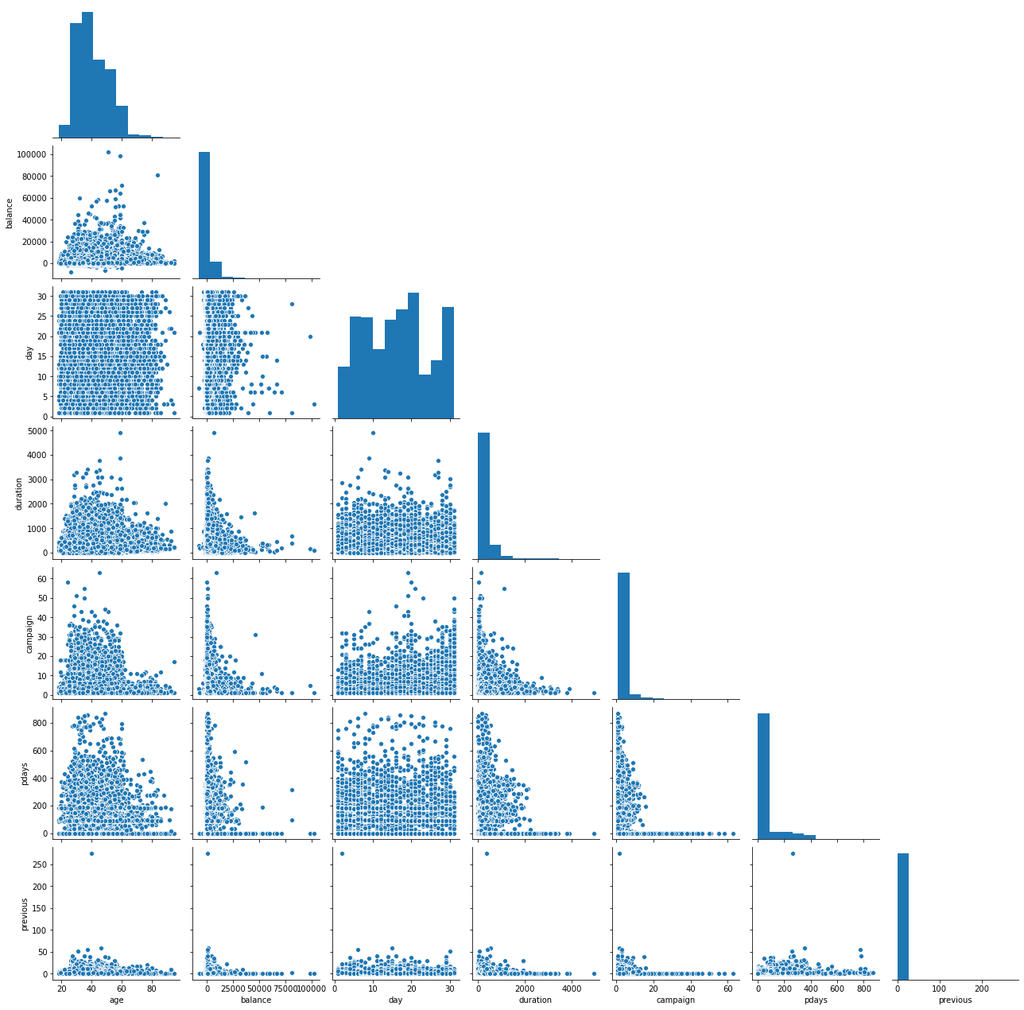

```python
sns.pairplot(raw_data, corner=True);
```

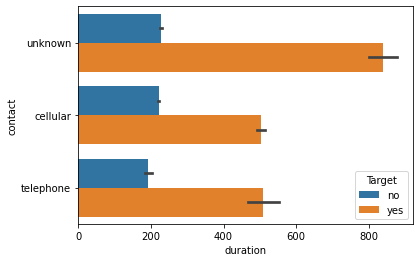

```python
# Longer contacts
sns.barplot(raw_data['duration'], raw_data['contact'], hue=raw_data['Target']);
```

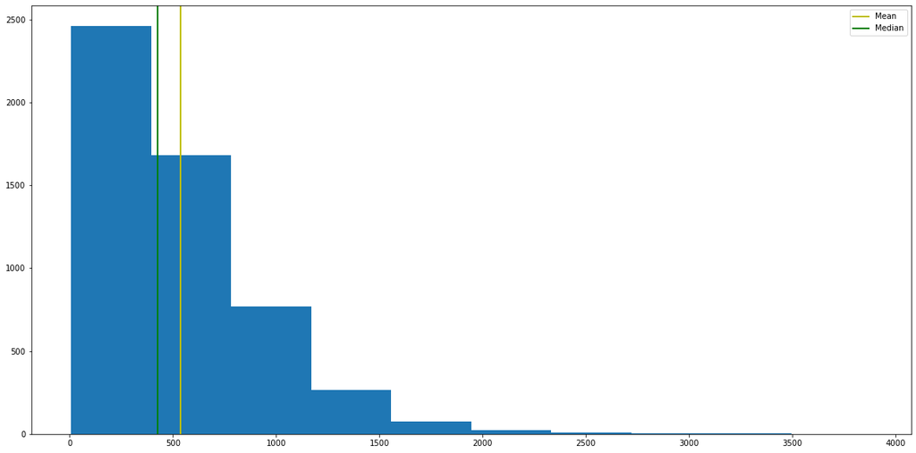

```python
# Comparison duration with result

dyes = raw_data[raw_data['Target'] == 'yes']['duration']

plt.figure(figsize=(20,10))
plt.hist(dyes)
plt.axvline(dyes.mean(), color='y', linewidth=2, label='Mean')
plt.axvline(dyes.median(), color='g', linewidth=2, label='Median')
plt.legend();
```

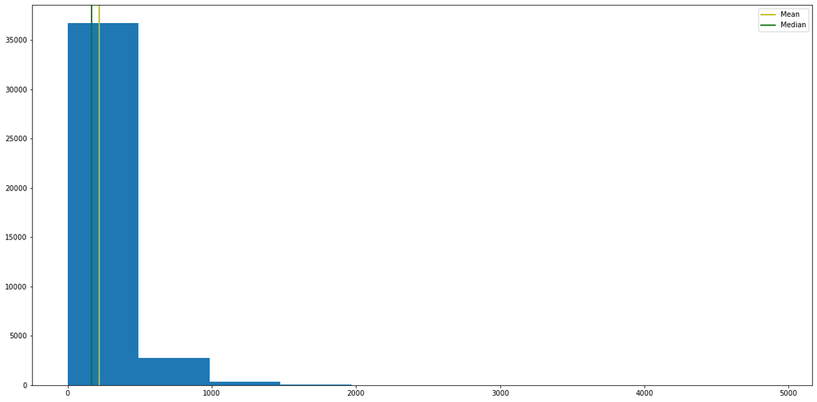

```python
# Comparison duration with result

dno = raw_data[raw_data['Target'] == 'no']['duration']

plt.figure(figsize=(20,10))
plt.hist(dno)
plt.axvline(dno.mean(), color='y', linewidth=2, label='Mean')
plt.axvline(dno.median(), color='g', linewidth=2, label='Median')
plt.legend();
```

*Beyond a duration of 221, you are much more likely to succeed in getting a term deposit.*